# Lab 3 Analyze stochastic data

## Lab 3: Analyze Stochastic Data

### Name: Gabriella Rivera

#### 1 Toss two coins

1. I am flipping two quarters

| Trial | Heads |
| --- | --- |
| 1 | 0 |
| 2 | 1 |
| 3 | 2 |
| 4 | 1 |
| 5 | 1 |
| 6 | 2 |
| 7 | 0 |
| 8 | 1 |
| 9 | 0 |
| 10 | 2 |
| 11 | 2 |
| 12 | 1 |
| 13 | 0 |
| 14 | 1 |
| 15 | 1 |
| 16 | 2 |
| 17 | 2 |
| 18 | 0 |
| 19 | 2 |
| 20 | 1 |

3. Summary:

0 heads -> 5

1 head -> 8

2 heads -> 7

```python
mean = (8 + 7) / 20
print(mean)
```

```
0.75
```

```python
results = [0, 0, 0, 0, 0, 1, 1, 1, 1, 1, 1, 1, 1, 2, 2, 2, 2, 2, 2, 2]
```

6. variance = sum((data_point - mean)^2) / N

```python
dp1 = (0 - 0.75) ** 2
dp2 = (1 - 0.75) ** 2
dp3 = (2 - 0.75) ** 2
dp4 = (1 - 0.75) ** 2
dp5 = (1 - 0.75) ** 2
dp6 = (2 - 0.75) ** 2
dp7 = (0 - 0.75) ** 2
dp8 = (1 - 0.75) ** 2
dp9 = (0 - 0.75) ** 2
dp10 = (2 - 0.75) ** 2
dp11 = (2 - 0.75) ** 2
dp12 = (1 - 0.75) ** 2
dp13 = (0 - 0.75) ** 2
dp14 = (1 - 0.75) ** 2
dp15 = (1 - 0.75) ** 2
dp16 = (2 - 0.75) ** 2
dp17 = (2 - 0.75) ** 2
dp18 = (0 - 0.75) ** 2
dp19 = (2 - 0.75) ** 2
dp20 = (1 - 0.75) ** 2

variance = (dp1 + dp2 + dp3 + dp4 + dp5 + dp6 + dp7 + dp8 + dp9 + dp10 + dp11 + dp12 + dp13 + dp14 + dp15 + dp16 + dp17 + dp18 + dp19 + dp20) / 20

print(variance)
```

```
0.7125
```

```python
import numpy as np
import matplotlib

print(np.std(results))
```

```
0.7681145747868608
```

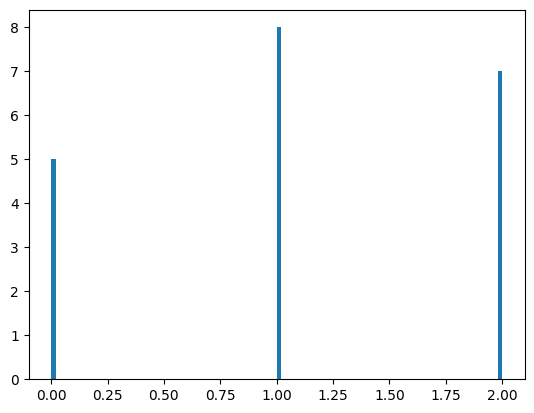

```python
import matplotlib.pyplot as plt

_ = plt.hist(results, bins=100)
```

9. No, the data does not contain outliers, nor can it contain outliers.
10. 20th percentile is 1/5. There are 20 datapoints, and therefore the 1/5th mark is the fourth data point. When we look at the ordered datapoints (which we need when we compute quantiles), the fourth data point is 0. Therefore the 20th percentile, or q(1/5) quantile is 0.
11. 80th percentile is 4/5. The 4/5th mark is the sixteenth data point, which is 2, so the 80th percentile (upper quintile), or q(4/5) quantile is 2.
12. The quantile share ration (QSR) can be computed as a sum of all values above the 0.8-th percentile, divided by the sum of values below 0.2-th percentile

```python
value_sum_80th = 2 + 2 + 2 + 2
value_sum_20th = 0 + 0 + 0 + 0
qsr = value_sum_80th / value_sum_20th
```

```
---------------------------------------------------------------------------
ZeroDivisionError                         Traceback (most recent call last)
Cell In[19], line 3
      1 value_sum_80th = 2 + 2 + 2 + 2
      2 value_sum_20th = 0 + 0 + 0 + 0
----> 3 qsr = value_sum_80th / value_sum_20th

ZeroDivisionError: division by zero
```

This cannot be done, for we cannot divide by 0